# analyze_temporal_features

Python 3.10.10 (main, Mar 21 2023, 18:45:11) [GCC 11.2.0]  
Type 'copyright', 'credits' or 'license' for more information  
IPython 8.7.0 -- An enhanced Interactive Python. Type '?' for help.

```python
import pathlib

import matplotlib.pyplot as plt
import pandas as pd
import seaborn as sns
import statsmodels.api as sm
import statsmodels.formula.api as smf
```

```python
cwd = pathlib.Path(__file__).parent
df_results = pd.read_csv(cwd.parent / 'local/eval_results/experiment_temporal_features.csv', index_col=0)
df_results["scope_estimator"] = pd.Categorical(df_results["scope_estimator"])
df_results["cols_used"] = df_results["cols_used"].str.replace('ft_numc_', '').fillna('None used')
df_results["uses_scope_1"] = df_results["cols_used"].str.contains('scope_1')
df_results["uses_scope_2"] = df_results["cols_used"].str.contains('scope_2')
df_results["uses_scope_3"] = df_results["cols_used"].str.contains('scope_3')
df_results["uses_year"] = df_results["cols_used"].str.contains('ft_numd_year')
df_results["uses_none"] = df_results["cols_used"].str.contains('None')
df_results["clueless_impact_sMAPE"] = df_results["clueless.sMAPE"] - df_results["raw.sMAPE"]
df_results["clueless_impact_jump_rate25"] = df_results["jump_rates.normal.percentile25"] - df_results["jump_rates.clueless.percentile25"]
df_results["clueless_impact_jump_rate50"] = df_results["jump_rates.normal.percentile50"] - df_results["jump_rates.clueless.percentile50"]
df_results["clueless_impact_jump_rate75"] = df_results["jump_rates.normal.percentile75"] - df_results["jump_rates.clueless.percentile75"]
df_results["clueless_impact_ex_sMAPE"] = df_results["clueless.sMAPE"] / df_results["raw.sMAPE"]

df_results
```

|  | repetition | cols_used | time | scope | imputer | fin_transformer | cat_transformer | scope_transformer | preprocessor | feature_selector | ... | uses_scope_1 | uses_scope_2 | uses_scope_3 | uses_year | uses_none | clueless_impact_sMAPE | clueless_impact_jump_rate25 | clueless_impact_jump_rate50 | clueless_impact_jump_rate75 | clueless_impact_ex_sMAPE |
| --- | --- | --- | --- | --- | --- | --- | --- | --- | --- | --- | --- | --- | --- | --- | --- | --- | --- | --- | --- | --- | --- |
| 0 | 1 | None used | 96.939466 | 1 | RevenueQuantileBucketImputer | PowerTransformer | TargetEncoder | LogTargetScaler | IIDPreprocessor | PCAFeatureReducer | ... | False | False | False | False | True | 2.220446e-16 | 0.000000 | 0.000000 | 4.440892e-16 | 1.000000 |
| 1 | 1 | ft_numd_year | 106.558607 | 1 | RevenueQuantileBucketImputer | PowerTransformer | TargetEncoder | LogTargetScaler | IIDPreprocessor | PCAFeatureReducer | ... | False | False | False | True | False | -3.366492e-03 | 0.022883 | 0.043471 | 1.003163e-01 | 0.995868 |
| 2 | 1 | prior_tg_numc_scope_1 | 110.165539 | 1 | RevenueQuantileBucketImputer | PowerTransformer | TargetEncoder | LogTargetScaler | IIDPreprocessor | PCAFeatureReducer | ... | True | False | False | False | False | 1.686624e-01 | 0.000002 | 0.000138 | -3.238904e-03 | 1.271940 |
| 3 | 1 | prior_tg_numc_scope_3 | 107.040075 | 1 | RevenueQuantileBucketImputer | PowerTransformer | TargetEncoder | LogTargetScaler | IIDPreprocessor | PCAFeatureReducer | ... | False | False | True | False | False | 3.247368e-02 | 0.000016 | 0.000176 | -2.148257e-04 | 1.049236 |
| 4 | 1 | prior_tg_numc_scope_2 | 102.557714 | 1 | RevenueQuantileBucketImputer | PowerTransformer | TargetEncoder | LogTargetScaler | IIDPreprocessor | PCAFeatureReducer | ... | False | True | False | False | False | 8.285261e-02 | 0.000050 | 0.000192 | -1.528162e-03 | 1.116369 |
| ... | ... | ... | ... | ... | ... | ... | ... | ... | ... | ... | ... | ... | ... | ... | ... | ... | ... | ... | ... | ... | ... |
| 315 | 20 | ft_numd_year\|prior_tg_numc_scope_1\|prior_tg_nu... | 76.379832 | 1 | RevenueQuantileBucketImputer | PowerTransformer | TargetEncoder | LogTargetScaler | IIDPreprocessor | PCAFeatureReducer | ... | True | False | True | True | False | 2.049033e-01 | 0.022707 | 0.037461 | 5.826096e-02 | 1.275388 |
| 316 | 20 | ft_numd_year\|prior_tg_numc_scope_1\|prior_tg_nu... | 69.837858 | 1 | RevenueQuantileBucketImputer | PowerTransformer | TargetEncoder | LogTargetScaler | IIDPreprocessor | PCAFeatureReducer | ... | True | True | False | True | False | 2.280249e-01 | 0.019109 | 0.032952 | 1.630828e-01 | 1.321032 |
| 317 | 20 | ft_numd_year\|prior_tg_numc_scope_3\|prior_tg_nu... | 79.947642 | 1 | RevenueQuantileBucketImputer | PowerTransformer | TargetEncoder | LogTargetScaler | IIDPreprocessor | PCAFeatureReducer | ... | False | True | True | True | False | 1.139248e-01 | 0.023742 | 0.050973 | 1.952492e-01 | 1.145113 |
| 318 | 20 | prior_tg_numc_scope_1\|prior_tg_numc_scope_3\|pr... | 79.999450 | 1 | RevenueQuantileBucketImputer | PowerTransformer | TargetEncoder | LogTargetScaler | IIDPreprocessor | PCAFeatureReducer | ... | True | True | True | False | False | 2.547252e-01 | 0.000054 | 0.000014 | -1.377903e-01 | 1.364247 |
| 319 | 20 | ft_numd_year\|prior_tg_numc_scope_1\|prior_tg_nu... | 72.880073 | 1 | RevenueQuantileBucketImputer | PowerTransformer | TargetEncoder | LogTargetScaler | IIDPreprocessor | PCAFeatureReducer | ... | True | True | True | True | False | 2.335333e-01 | 0.017091 | 0.018305 | -1.175254e-01 | 1.324870 |

320 rows × 514 columns

# Correlation Matrix

**Shows:** A correlation matrix as heatmap showing the linear relationships between the different metrics used in this analysis

**Notes:**

- *raw.offset_percentiles* are the rate to which the prediction is different from the true value. For instance, at raw.offset_percentile 50% *the median rate of being off from the true value is 1.XX*
- Jump rates are similar in intuition but computed in a completely different way. They represent the percentile in jump-rates of scopes by yearly transition after scope imputations. These yearly transitions are not cleaned by whether the transition years where reported or not. For instance, a mean jump-rate of 1.5 says that after scope imputations of our model on average the scope of any year jumps 50% compared to the previous year.
- The jump-rates are normalised. Hence a jump-rate of 1.5 could mean a year increased or decreased by 50%.

**Observations:**

**Interpretations:**

- sMAPE and MAE can be interpreted interchangably.
- A relationship between the sMAPE metric and the jump-rate exists in the lower percentile region.
- The relationship between jump rates and offsets is important. It tells us that an improvement of our prediction offsets could lead to an improvement in jump rates. One could say the same about sMAPE/MAE, too. But only for the lower percentile regions of jump-rates.
- However, these relationships break down in higher percentile regions. Meaning, high yearly jumps do not appear to be an issue of prediction accuracy. Maybe those correlate with the lack of input data or the existence of missing values.

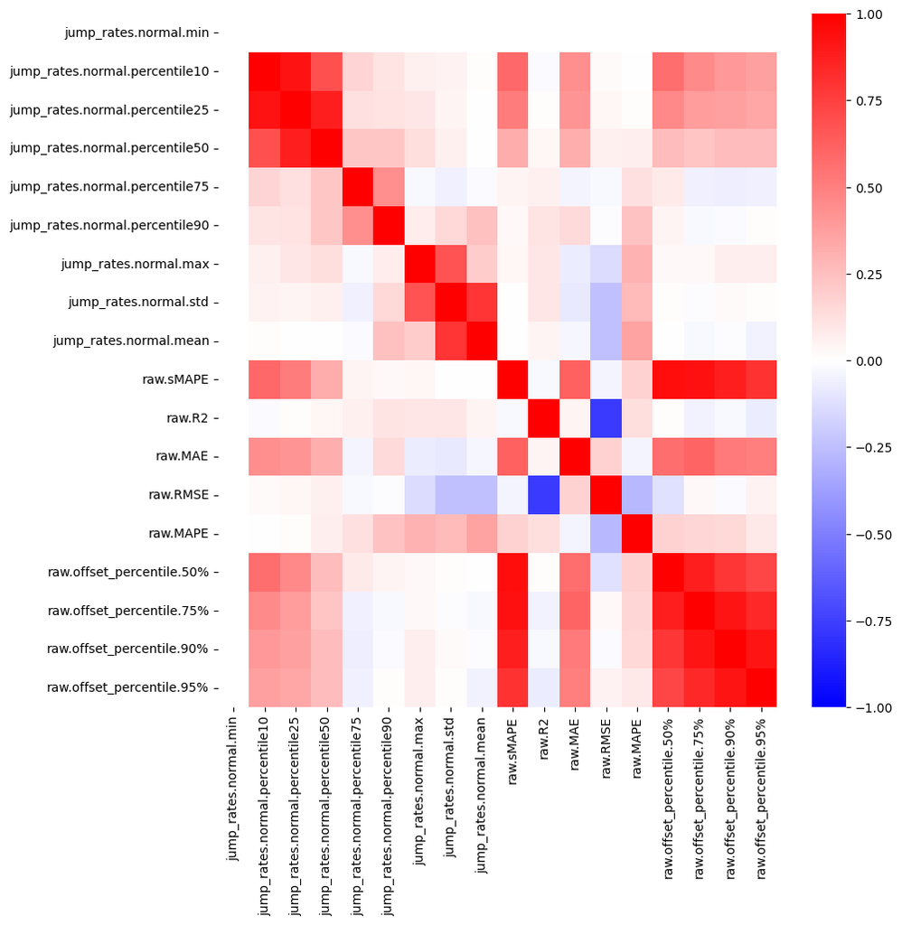

```python
fig = plt.figure(figsize=(10, 10))
corr_matrix = df_results.filter(regex="^(raw\.|jump_rates\.normal)").corr()
sns.heatmap(corr_matrix, cmap="bwr", vmax=1, vmin=-1)
plt.show()
```

# Effects of temporal hacks on sMAPE

**Shows:** Two bar plots showing the sMPAE in relationship to the temporal *hack* that was used to introduce time as a feature.

### Notes

- The first plot shows the sMAPE on validation-data if the features remain present, and the second (*clueless*) if the features are not present.
- In the case of non-existing columns, they will be imputed using an imputation strategy.
- These are only results for *scope 1*. Doing the same for scope 2 and 3 would make the analysis more complex and time-consuming

### Observations

- Scope 1 sMAPE is lowest if the previous year was used as a feature during training.
- Introducing the year as feature always leads worse sMAPE results
- Introducing previous scope 2or 3 to predict scope 1 seems detrimental to the model.
- No usage of any hack does not impact the non-existence of the *hacky* features. That's quite trivial but an important sanity check. (Found a bug due to this earlier.)

### Interpretations

- These results show that it might not be reasonable to introduce year as a feature.
- That previous scope 2 and scope 3 don't help improving scope 1 was expected.
- The use of previous scope 1 is not that clear, because the model does seem to over rely on that feature.

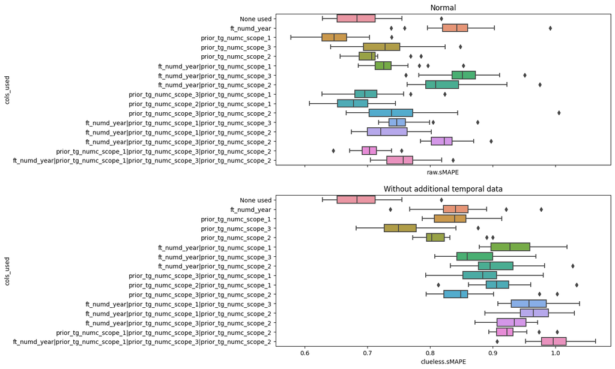

```python
fig, (ax1, ax2) = plt.subplots(2, 1, figsize=(10, 10), sharex=True)

sns.boxplot(data=df_results, x="raw.sMAPE", y="cols_used", ax=ax1)
ax1.set_title('Normal')
sns.boxplot(data=df_results, x="clueless.sMAPE", y="cols_used", ax=ax2)
ax2.set_title('Without additional temporal data')
plt.show()
```

# Impact on sMAPE if hacky features are omitted

**Shows:** Barplot which displays the clueness-less impact on the model

### Notes

- Clueness-less means that the model was trained using a hack but during inference had no access to that feature. Hence, the model was forced to use an imputation strategy for the whole validation set.
- Lower number means lesser impact. More robust model.

### Observations

- If no hack is used, there is no impact if the features are missing. Also there's no variation. Again, trivial but important sanity check.
- Impact is also very low for using year as a feature. This time with variation. Meaning sometimes, the model becomes even better if trained with year as a feature and then omitting it.
- High impact for the prev-scope-1 column. Model loses around .20 in sMAPE without the feature.

### Interpretations

The results of the year-feature are even more conclusive here. If the model is trained on year and then sometimes becomes better omitting it, the year is decisively bad for the model. The observation, that omitting the feature prev-scope-1 has such a high impact shows how much the model relies on the feature. It also shows how important previous years are. But this importance cannot be captured by just adding year.

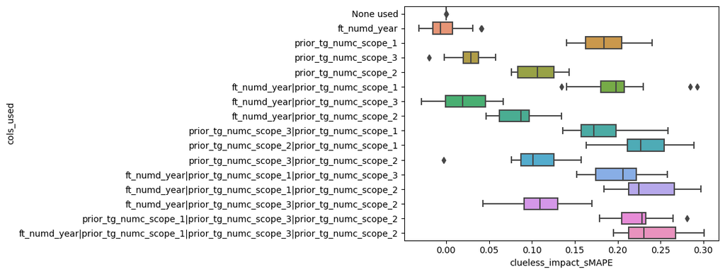

```python
sns.boxplot(data=df_results, x="clueless_impact_sMAPE", y="cols_used")
plt.show()
```

# Effects of temporal hacks on jump rates

**Shows:** Two bar plots showing the jump rates in relationship to the temporal *hack* that was used to introduce time as a feature.

### Notes

- The plot shows the 50th percentile.

### Interpretations

- These results are hard to interpret.

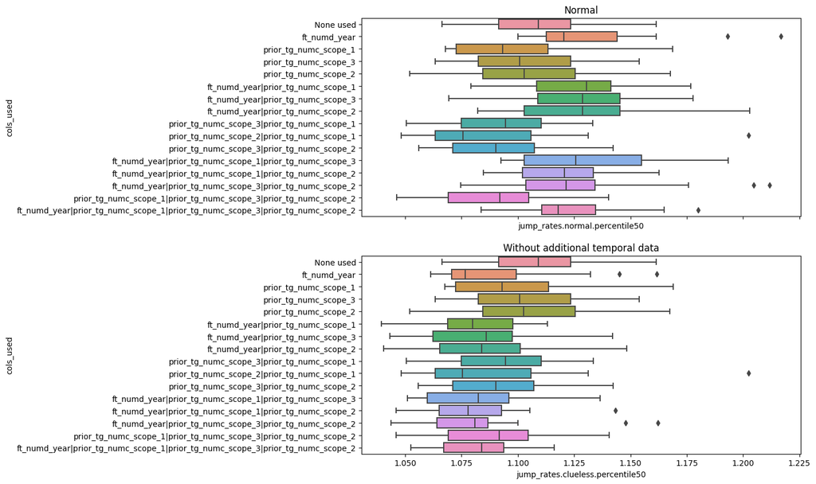

```python
fig, (ax1, ax2) = plt.subplots(2, 1, figsize=(10, 10), sharex=True)
sns.boxplot(data=df_results, x="jump_rates.normal.percentile50", y="cols_used", ax=ax1)
ax1.set_title('Normal')
sns.boxplot(data=df_results, x="jump_rates.clueless.percentile50", y="cols_used", ax=ax2)
ax2.set_title('Without additional temporal data')
plt.show()
```

# Impact on jump rates if hacky features are omitted

**Shows:** Barplot which displays the clueness-less impact on the model

### Observations

- In many cases omitting the hacky feature does not have an effect on the jump-rate unless year was involved.

### Interpretations

- Need to reevaluate in light of the previous results

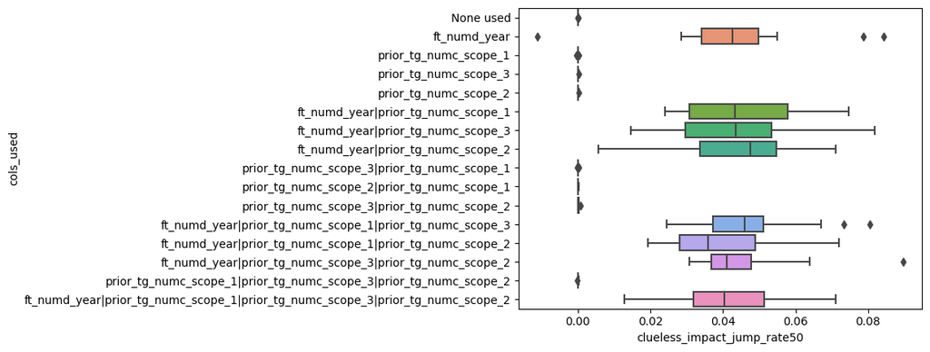

```python
sns.boxplot(data=df_results, x="clueless_impact_jump_rate50", y="cols_used")
plt.show()
```

# Relationship between jump-rate and sMAPE

**Shows:** Scatterplot

### Notes

This plot uses jump-rates of percentile 25. For, higher jump-rate percentile regions the relationship vanishes.

### Observations

- Clear relationship between sMAPE and jump-rates on percentile 25

### Interpretations

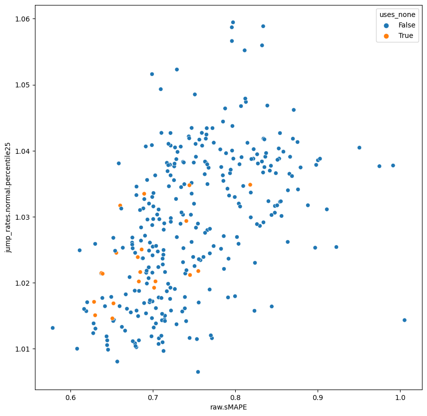

```python
fig = plt.figure(figsize=(10, 10))
sns.scatterplot(data=df_results, y="jump_rates.normal.percentile25", x="raw.sMAPE", hue="uses_none")
plt.show()
```

# Marginal effect of the hacks

**Shows:** Bar plots of the marginal effect of introducing a temporal hack

### Notes

- The next few plots all follow the same principal: Showing the effects of introducing a certain hack even if other hacks where also involved.Fon instance, if prev-scope-1 is the focus, all combinations with prev-scope-1 (prev-scope-1 with year, prev-scope-1 with prev-scope-2, etc.) are included.

### Observations

- Using no hack leads to a narrow range of sMAPE and jump-rates. Trivial result.
- Involving year leads to worse sMAPE and jump-rates
- Involving prev-scope-1 leads to strong improvements for sMAPE but small in terms of jump-rates
- Similar effects with prev-scope-2 as with prev-scope-1 but much much weaker
- Involvement of prev-scope-3 makes sMAPE worse but still improves a little on jump-rates

### Interpretations

Many of the results were already drawn beforehand. However, one additional insight is given by the consistent improvement of jump-rates for all three prev-scope hacks. Cannot think of an explanation.

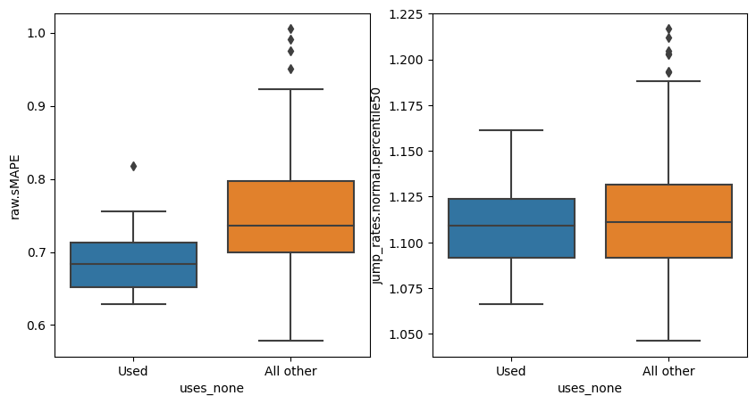

```python
col = "uses_none"
def plot_isolated_effect(df_results:pd.DataFrame, col):
    df = df_results.copy()
    df[col] = df[col].replace({True:"Used", False:"All other"})
    fig, (ax1, ax2) = plt.subplots(1, 2, figsize=(10, 5), sharex=True)
    sns.boxplot(data=df, y="raw.sMAPE", x=col, ax=ax1)
    sns.boxplot(data=df, y="jump_rates.normal.percentile50", x=col, ax=ax2)

    plt.show()

plot_isolated_effect(df_results, "uses_none")
```

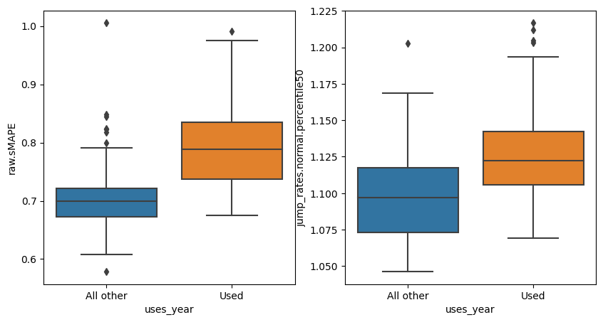

```python
plot_isolated_effect(df_results, "uses_year")
```

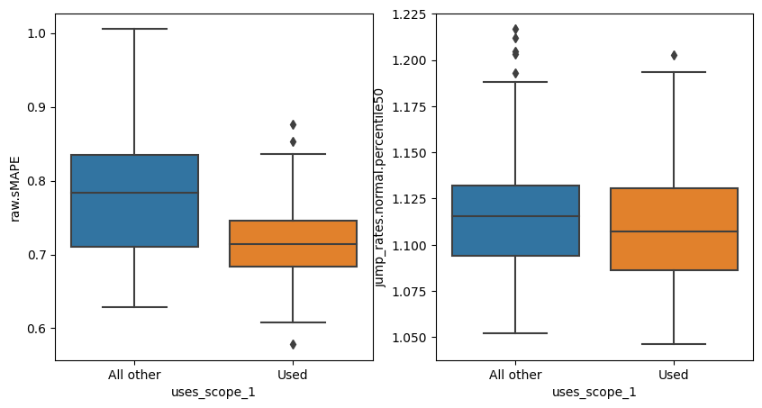

```python
plot_isolated_effect(df_results, "uses_scope_1")
```

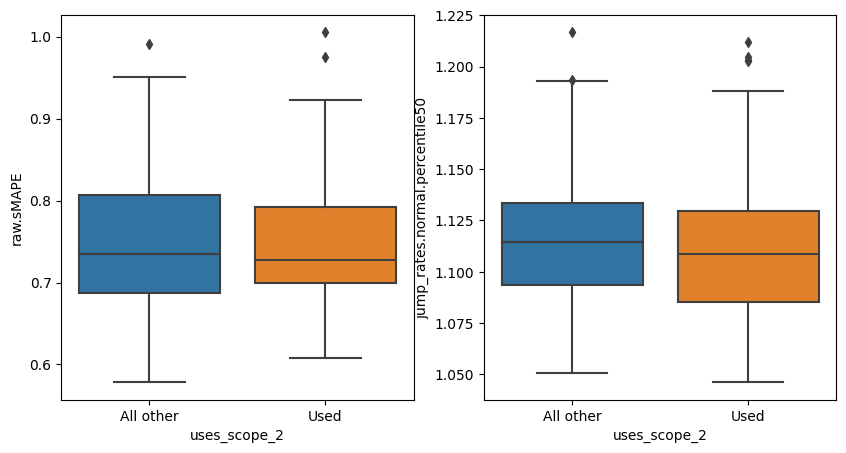

```python
plot_isolated_effect(df_results, "uses_scope_2")
```

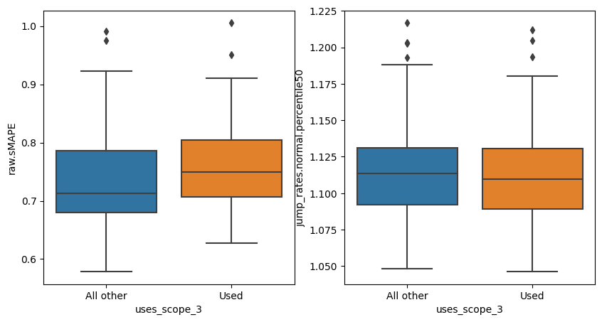

```python
plot_isolated_effect(df_results, "uses_scope_3")
```